# Project 3

Cao Fang

December 1, 2019

## Data sources and Background

Data provided by the Urban Ministries of Durham on their services of homeless shelter. The dataset used for this report are health insurance at entry, UDES survey data, baseline client information and the vulnerability assessment at entry.

## Goals

The goal for this visualization is to answer the questions: - What are the demographic composition of people in homeless shelter ? -What causes people to stay longer in the shelters? - what causes people to score higher in the vulnerability index? -Are people properly rehoused based on their assessment

## Baseline Demographic Characteristics

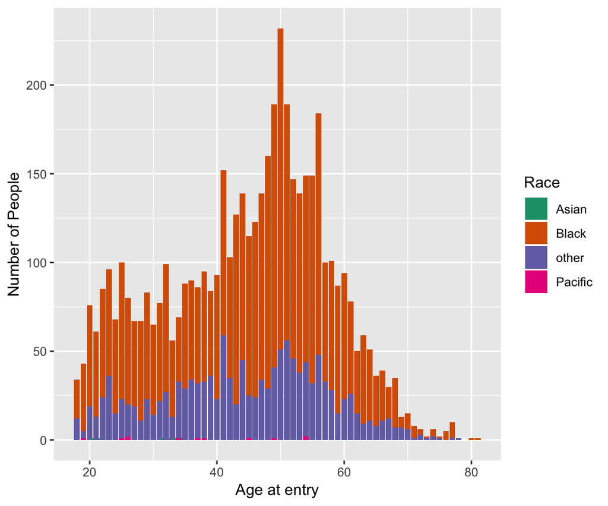

# Baseline Health Insurance Utilization

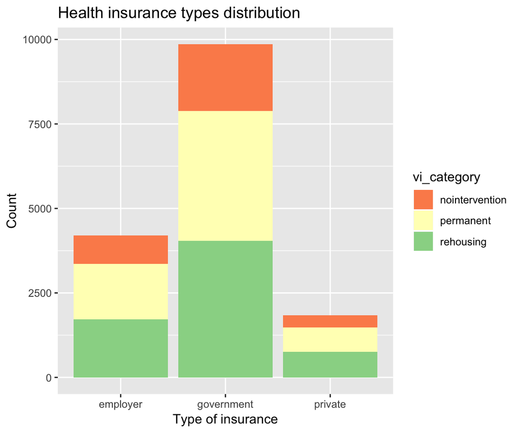

As seen from above, most people are on Government insurance programs such as COBRA, CHIP, MEDICARE, MEDICAID and VA Health insurance.

## What determines how long clients stay at those shelters ?

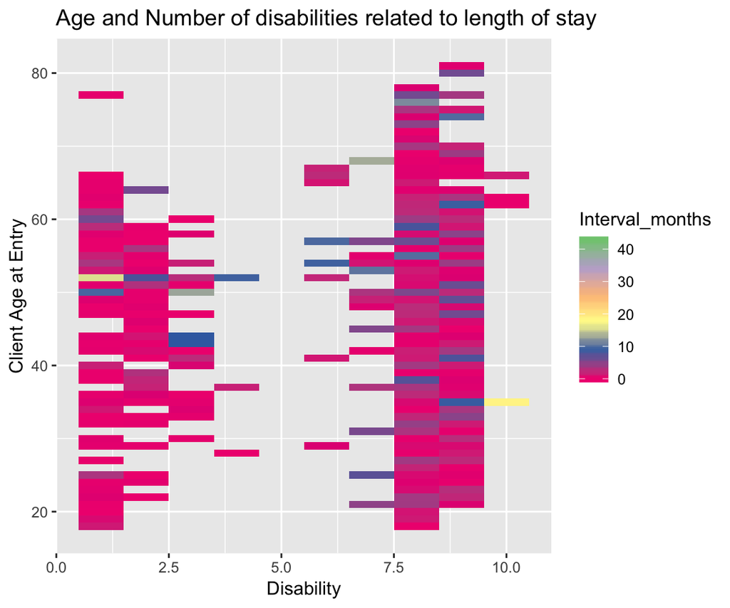

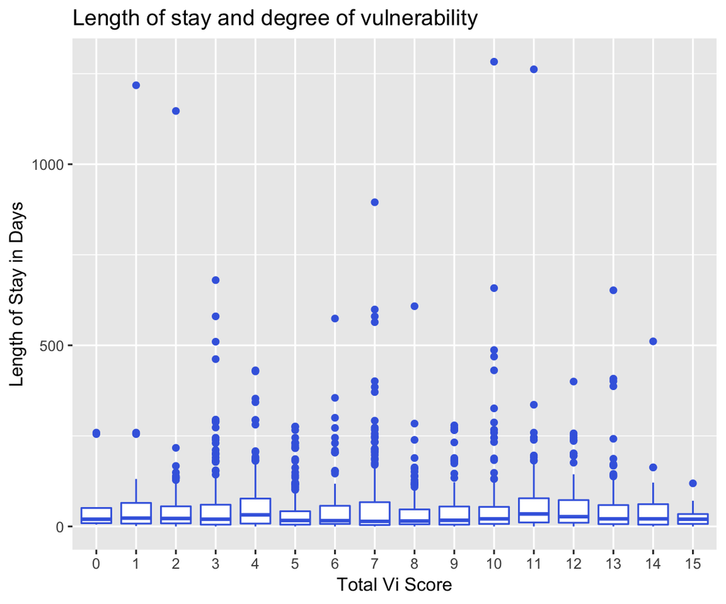

The assessment called Service Prioritization Assessment Tool was used to assess the degree of risk and vulnerabilities for each client. The higher the vi score the more vulnerable the client is. As seen from the graph, there isn’t much difference across difference vi scores.

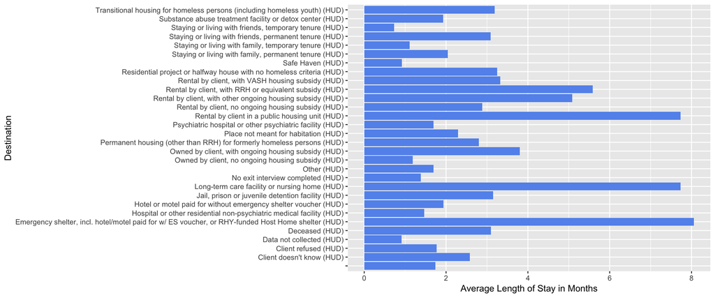

## What determines the Client vulnerabilities?

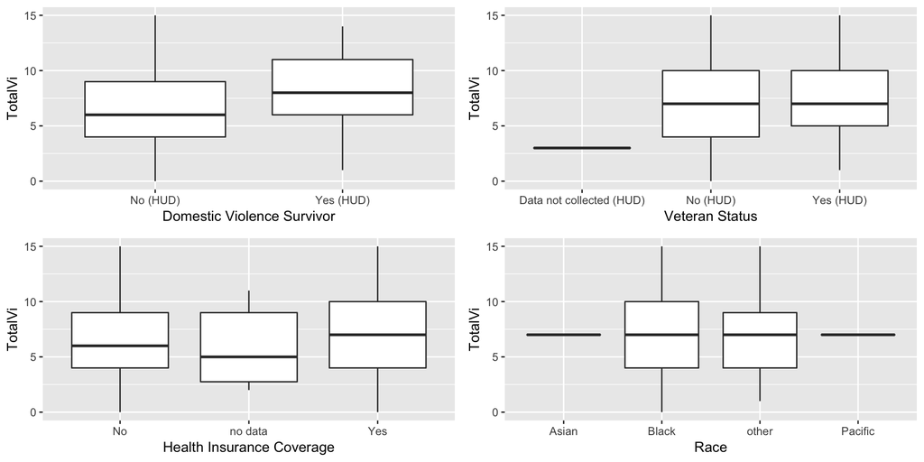

This plot shows the relationship between client vulnerability index and different factors. As seen from the graphs above, none of the factors show outstanding patterns despite being victims of domestic violence.

## Did UMD successfully rehouse those people based on the vulnerability index ?

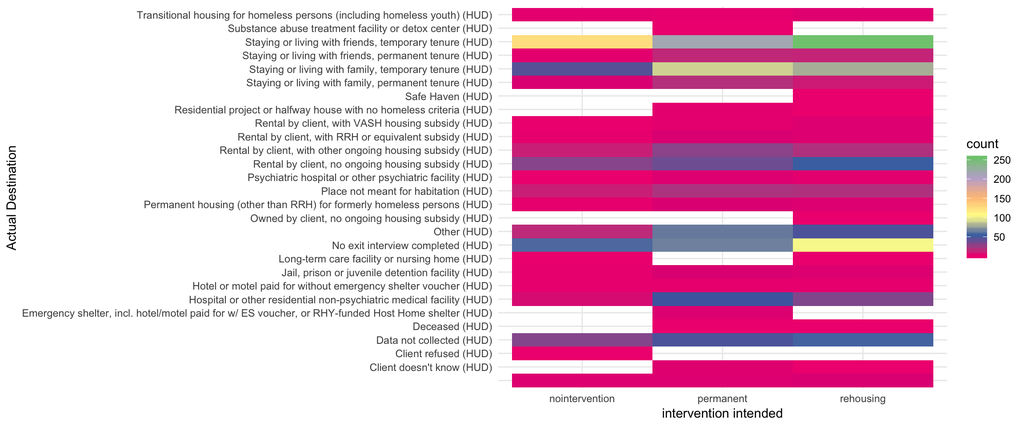

Looks like from the graph that there is no clear pattern of rehousing based on their baseline assessment. For most of clients the destination are usually still friends or family while rehousing for homeless people or trasnistional housing are not top destinations. There are almost no difference across the three categories of vulnerabilities.

## Conclusion

Overall, UMD might need to consider more rigorous plan to help people with high risks and high number of disabilities re-house after they leave homeless shelter.